# Project 2 - Analysis of Sales Data

Tran Nguyen

## Description of Project

Assume that a company called Global Markets Inc. operates 127 grocery stores across the country. They collect data relating to annual sales for each of their stores. The data is stored in the data file “global.txt”. A description of the fields in this dataset is as follows:

| Variable | Description |
| --- | --- |
| **`Sales`** | Annual sales, in $1000’s. |
| **`SqFt`** | Size of store, measured in 1000’s of square feet. |
| **`Inv`** | Value of inventory, in $1000’s. |
| **`Adv`** | Annual advertising budget, in $1000’s. |
| **`Pop`** | Population served by store, in 1000’s of people. |
| **`MedInc`** | Median income of population, in $1000’s. |

Our goal in this project will be to create a multiple linear regression model that attempts to predict `Sales` as a function of some combination of the remaining five variables.

## Part A: Loading and Exploring the Data

Load the data contained in the text file into a data frame.

```r
df <- read.table("global.txt", sep = "\t", header = TRUE)
```

Create a summary of the data frame.

```r
sum(df)
```

```
[1] 94950.4
```

Use `pairs()` to create a pairs plot showing scatterplots of all pairs of variables in the data frame.

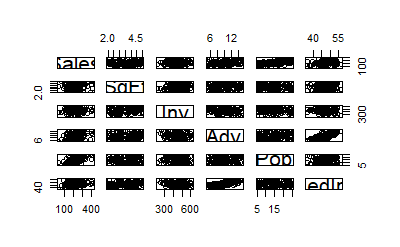

```r
pairs(df)
```

Use `cor()` to create a correlation matrix showing the correlations of all pairs of variables in the data frame.

```r
cor(df)
```

```
            Sales        SqFt         Inv        Adv         Pop      MedInc
Sales  1.00000000  0.11836569  0.01536351  0.3225686  0.60565862  0.22534130
SqFt   0.11836569  1.00000000  0.18583352  0.1718911 -0.09221776  0.08438425
Inv    0.01536351  0.18583352  1.00000000 -0.1959067 -0.09193074 -0.16394803
Adv    0.32256857  0.17189110 -0.19590668  1.0000000  0.17582227  0.74181612
Pop    0.60565862 -0.09221776 -0.09193074  0.1758223  1.00000000  0.12723424
MedInc 0.22534130  0.08438425 -0.16394803  0.7418161  0.12723424  1.00000000
```

`Pop` appears to have the strongest linear relationship with `Sales`.

## Part B: Consider the Full Model

Create a model by regressing `Sales` against all of the other five variables at once. Then display a summary of this model.

```r
m1 <- lm(Sales ~ SqFt + Inv + Adv + Pop + MedInc, df)
summary(m1)
```

```
Call:
lm(formula = Sales ~ SqFt + Inv + Adv + Pop + MedInc, data = df)

Residuals:
     Min       1Q   Median       3Q      Max
-136.274  -34.762   -1.126   31.026  165.410

Coefficients:
            Estimate Std. Error t value Pr(>|t|)
(Intercept) -0.45585   74.50325  -0.006   0.9951
SqFt         9.83422    5.95443   1.652   0.1012
Inv          0.07853    0.06245   1.258   0.2110
Adv          6.02217    2.80285   2.149   0.0337 *
Pop          7.01995    0.83359   8.421 8.91e-14 ***
MedInc      -0.20129    1.73172  -0.116   0.9077
---
Signif. codes:  0 ‘***’ 0.001 ‘**’ 0.01 ‘*’ 0.05 ‘.’ 0.1 ‘ ’ 1

Residual standard error: 54.53 on 121 degrees of freedom
Multiple R-squared:  0.4407,    Adjusted R-squared:  0.4176
F-statistic: 19.07 on 5 and 121 DF,  p-value: 5.938e-14
```

This model seems good. The p-value of 5.938e-14 indicates that we should reject the null hypothesis that other five variables have no impact on Sales. The resuls also show that Pop is highly significant controlling (with p-value of 8.91e-14). The fitted model is given by: $ = -0.45585 + 9.83422 SqFt + 0.07853 Inv + 6.02217 Adv + 7.01995 Pop - 0.20129 MedInc $. For any given inventory value, advertising budget, population and median income of population, improving in a size of store will lead to an extra $9834 in sales. Similarly, for any given size of store, inventory value, advertising budget and population, an additional median income of population will lead to a decrease of $201 in sales.

The r-squared value is given by `r^2 = 0.4407`, which tells us that nearly 44.07% of the variances are explained by the model. The residual standard error is equal to 54.53, means the percentage error is 45%.

## Part C: Model Selection

Based on your analysis up to this point, select one of the five potential predictors and create a simple linear regression model using only this one predictor. Create a summary of the model.

```r
m2 <- lm(Sales ~ Pop, df)
summary(m2)
```

```
Call:
lm(formula = Sales ~ Pop, data = df)

Residuals:
     Min       1Q   Median       3Q      Max
-164.141  -39.951    3.181   33.971  180.695

Coefficients:
            Estimate Std. Error t value Pr(>|t|)
(Intercept) 116.5682    13.3164   8.754 1.20e-14 ***
Pop           7.2474     0.8517   8.510 4.57e-14 ***
---
Signif. codes:  0 ‘***’ 0.001 ‘**’ 0.01 ‘*’ 0.05 ‘.’ 0.1 ‘ ’ 1

Residual standard error: 57.08 on 125 degrees of freedom
Multiple R-squared:  0.3668,    Adjusted R-squared:  0.3618
F-statistic: 72.42 on 1 and 125 DF,  p-value: 4.571e-14
```

The fitted model is given by the following equation: $ = 116.5682 + 7.2474 Pop $

Now add variables into the model one at a time, creating a summary and providing an evaluation of the model at each step. If a variable that you have added fails to improve the model, then remove it and add another variable. Explain your decisions at each step.

Continue this process until you have a satisfactory model. All of the coefficients in your final model should pass their t-tests with at the 5% level of significance.

```r
m3 <- lm(Sales ~ Pop + SqFt, df)
summary(m3)
```

```
Call:
lm(formula = Sales ~ Pop + SqFt, data = df)

Residuals:
     Min       1Q   Median       3Q      Max
-166.854  -38.305    0.568   32.238  171.294

Coefficients:
            Estimate Std. Error t value Pr(>|t|)
(Intercept)  61.5694    25.5006   2.414   0.0172 *
Pop           7.4413     0.8377   8.883 6.23e-15 ***
SqFt         14.6362     5.8314   2.510   0.0134 *
---
Signif. codes:  0 ‘***’ 0.001 ‘**’ 0.01 ‘*’ 0.05 ‘.’ 0.1 ‘ ’ 1

Residual standard error: 55.91 on 124 degrees of freedom
Multiple R-squared:  0.3974,    Adjusted R-squared:  0.3877
F-statistic: 40.89 on 2 and 124 DF,  p-value: 2.292e-14
```

The p-value of 2.292e-14 concludes we have a relationship between Sales, Pop and SqFt. The r-squared value is given by `r^2 = 0.3974`, which tells us that nearly 39.74% of the variances are explained by the model. The residual standard error is equal to 55.91, means the percentage error is 45%.

```r
m4 <- lm(Sales ~ Pop + Adv , df)
summary(m4)
```

```
Call:
lm(formula = Sales ~ Pop + Adv, data = df)

Residuals:
     Min       1Q   Median       3Q      Max
-137.643  -37.061    0.861   32.196  168.112

Coefficients:
            Estimate Std. Error t value Pr(>|t|)
(Intercept)  64.7604    20.6875   3.130  0.00218 **
Pop           6.7783     0.8349   8.119 3.98e-13 ***
Adv           5.9562     1.8638   3.196  0.00177 **
---
Signif. codes:  0 ‘***’ 0.001 ‘**’ 0.01 ‘*’ 0.05 ‘.’ 0.1 ‘ ’ 1

Residual standard error: 55.09 on 124 degrees of freedom
Multiple R-squared:  0.415, Adjusted R-squared:  0.4056
F-statistic: 43.98 on 2 and 124 DF,  p-value: 3.661e-15
```

## Part E: Residual Analysis

Create a residual plot for your final model.

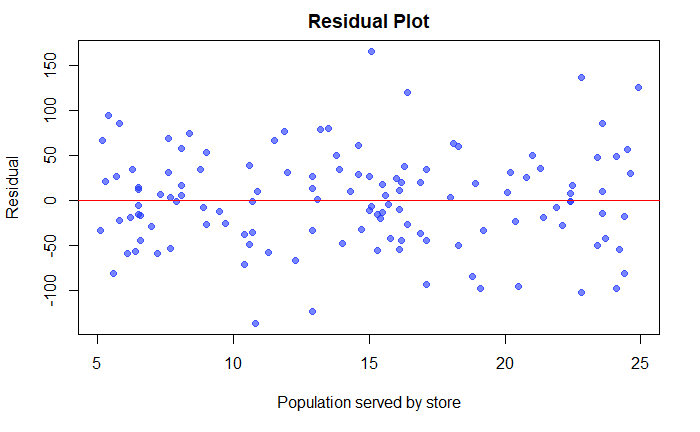

```r
res <- m1$residuals
fitted <- m1$fitted.values
plot(res ~ Pop, df, pch=19, col=rgb(0.1, 0.2, 1.0, 0.6),
     main="Residual Plot", xlab="Population served by store", ylab="Residual") ; abline(h = 0, col = "red")
```

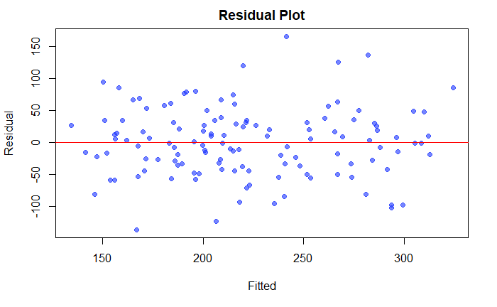

```r
plot(res ~ fitted, pch=19, col=rgb(0.1, 0.2, 1.0, 0.6),
     main="Residual Plot", xlab="Fitted", ylab="Residual") ; abline(h = 0, col = "red")
```

We can see that the distribution of the residuals is quite symmetrical. This is a good plot suggesting an evidence of equal variance.

Create a histogram of the residuals in your final model, using 20 breaks.

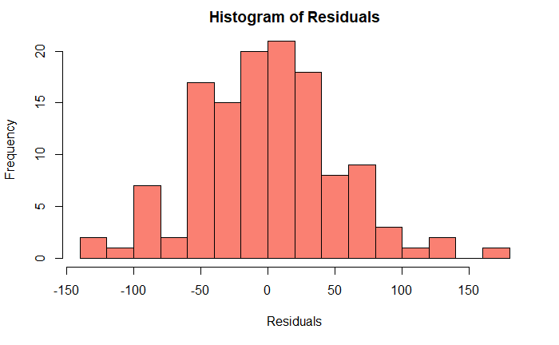

```r
hist(m1$residuals, breaks=20, col = "salmon", main = "Histogram of Residuals", xlab = "Residuals")
```

The residuals of the fitted model has a normal distribution. The histogram provides strong evidence that our residuals are normally distributed with a mean of 0.

Create a qq-plot of the residuals in your final model.

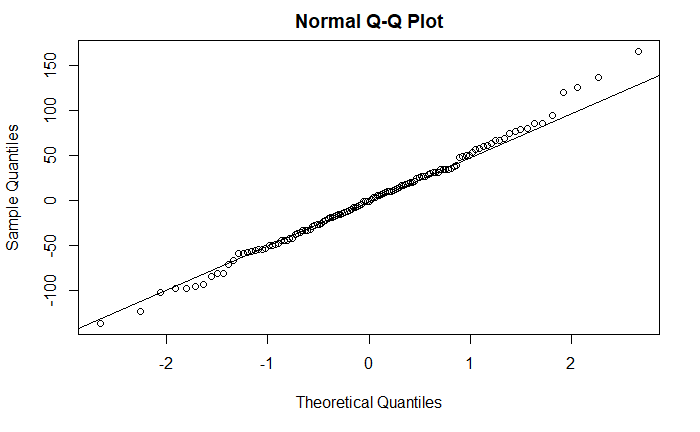

```r
qqnorm(m1$residuals)
qqline(m1$residuals)
```